# 200514_plotHeatShock

Erin Nishimura

05/14/2020

## Load Packages

dplyr

ggplot2

```
## [1] script initiated on
```

```
## [1] "2020-05-22 09:44:32 MDT"
```

## Import

Import the data. Organize the order of factor data. Clean up the dataframe.

```r
# import the data
clusterTable <- read.table(file = "../1_input/figure7_sourcedata_200514.txt", header = TRUE)


RNAsPerClusterTable <- read.table(file = "../1_input/figure7_sourcedata2_200520.txt", header = TRUE)
```

## Exploratory Data Analysis

Explore the data. Determine the dimensions & the data structure

```r
dim(clusterTable)
```

```
## [1] 109   9
```

```r
head(clusterTable)
```

```
##   Condition  Stage         Image_n  Probe n_RNA_clusters Overlap n_P_granules
## 1        HS 2-cell Image_10_191016 B04957            135      50          108
## 2        HS 2-cell Image_10_191016  set-3             33      21          108
## 3        HS 4-cell Image_03_191010 B04957             98      15          146
## 4        HS 4-cell Image_03_191010  set-3             30      11          146
## 5        HS 4-cell Image_04_191016 B04957            124      20          126
## 6        HS 4-cell Image_04_191016  set-3             16       8          126
##   Fract_clusters_in_Pgran Fract_Pgran_in_clusters
## 1               0.3703704              0.46296296
## 2               0.6363636              0.19444444
## 3               0.1530612              0.10273973
## 4               0.3666667              0.07534247
## 5               0.1612903              0.15873016
## 6               0.5000000              0.06349206
```

```r
str(clusterTable)
```

```
## 'data.frame':    109 obs. of  9 variables:
##  $ Condition              : Factor w/ 2 levels "HS","No_HS": 1 1 1 1 1 1 1 1 1 1 ...
##  $ Stage                  : Factor w/ 7 levels "12-cell","14-cell",..: 4 4 5 5 5 5 5 5 5 5 ...
##  $ Image_n                : Factor w/ 41 levels "Image_01_191014",..: 25 25 5 5 9 9 16 16 23 23 ...
##  $ Probe                  : Factor w/ 3 levels "B04957","gpd-2",..: 1 3 1 3 1 3 1 3 1 3 ...
##  $ n_RNA_clusters         : int  135 33 98 30 124 16 47 12 107 18 ...
##  $ Overlap                : int  50 21 15 11 20 8 12 9 41 11 ...
##  $ n_P_granules           : int  108 108 146 146 126 126 79 79 180 180 ...
##  $ Fract_clusters_in_Pgran: num  0.37 0.636 0.153 0.367 0.161 ...
##  $ Fract_Pgran_in_clusters: num  0.463 0.1944 0.1027 0.0753 0.1587 ...
```

```r
# Set factor levels
clusterTable$Condition <- factor(clusterTable$Condition, levels = c("No_HS", "HS"))

clusterTable$Probe <- factor(clusterTable$Probe, levels = c("gpd-2", "set-3", "B04957"))
str(clusterTable)
```

```
## 'data.frame':    109 obs. of  9 variables:
##  $ Condition              : Factor w/ 2 levels "No_HS","HS": 2 2 2 2 2 2 2 2 2 2 ...
##  $ Stage                  : Factor w/ 7 levels "12-cell","14-cell",..: 4 4 5 5 5 5 5 5 5 5 ...
##  $ Image_n                : Factor w/ 41 levels "Image_01_191014",..: 25 25 5 5 9 9 16 16 23 23 ...
##  $ Probe                  : Factor w/ 3 levels "gpd-2","set-3",..: 3 2 3 2 3 2 3 2 3 2 ...
##  $ n_RNA_clusters         : int  135 33 98 30 124 16 47 12 107 18 ...
##  $ Overlap                : int  50 21 15 11 20 8 12 9 41 11 ...
##  $ n_P_granules           : int  108 108 146 146 126 126 79 79 180 180 ...
##  $ Fract_clusters_in_Pgran: num  0.37 0.636 0.153 0.367 0.161 ...
##  $ Fract_Pgran_in_clusters: num  0.463 0.1944 0.1027 0.0753 0.1587 ...
```

## Statistics - Percentage of clusters co-localizing with P granule markers

Calculate a set of p values determining differences between heat shock and non-heat shock conditions, this time describing differences between the metric that shows the fraction of probset-specific mRNA clusters to overlap with P granule markers.

```r
# Calculate p-values for each probe set
# Metric: the fraction of mRNA clusters overlapping with P granules
# Conditions: heat shock versus no heat shock conditions

# Calculate the t-test - Fract_clusters_in_Pgran
calculate_fract_pvalue <- function(data, Probeset){
  # Filter for given probeset
  transcript_quantTable <- data %>%
    filter(Probe == Probeset)

  # Save the p-value
  ttestresult <- t.test(Fract_clusters_in_Pgran*100 ~ Condition, data = transcript_quantTable)

  # Return the p-value
  return(ttestresult)
}
```

```
## [1] "t.test calculation - gpd-2 Probe set; Fraction of gpd-2 clusters co-localizing to P granules in non-heat shock versus heat shock conditions:"
```

```
##
##  Welch Two Sample t-test
##
## data:  Fract_clusters_in_Pgran * 100 by Condition
## t = -6.9264, df = 25.973, p-value = 2.373e-07
## alternative hypothesis: true difference in means is not equal to 0
## 95 percent confidence interval:
##  -28.94305 -15.69517
## sample estimates:
## mean in group No_HS    mean in group HS
##            6.967521           29.286632
```

```
## [1] "t.test calculation - set-3 Probe set; Fraction of set-3 clusters co-localizing to P granules in non-heat shock versus heat shock conditions:"
```

```
##
##  Welch Two Sample t-test
##
## data:  Fract_clusters_in_Pgran * 100 by Condition
## t = -3.48, df = 33.041, p-value = 0.00143
## alternative hypothesis: true difference in means is not equal to 0
## 95 percent confidence interval:
##  -37.485360  -9.826464
## sample estimates:
## mean in group No_HS    mean in group HS
##            29.39815            53.05406
```

```
## [1] "t.test calculation - B04957 Probe set; Fraction of B049457 clusters co-localizing to P granules in non-heat shock versus heat shock conditions:"
```

```
##
##  Welch Two Sample t-test
##
## data:  Fract_clusters_in_Pgran * 100 by Condition
## t = -5.3319, df = 22.917, p-value = 2.079e-05
## alternative hypothesis: true difference in means is not equal to 0
## 95 percent confidence interval:
##  -21.313800  -9.396525
## sample estimates:
## mean in group No_HS    mean in group HS
##            3.913355           19.268517
```

## Plot - Figure 7B - Percentage of clusters co-localizing with P granule markers

For each probeset, plot the percentage of RNA clusters that co-localize to P granules under non-heat schock and heat shock conditions.

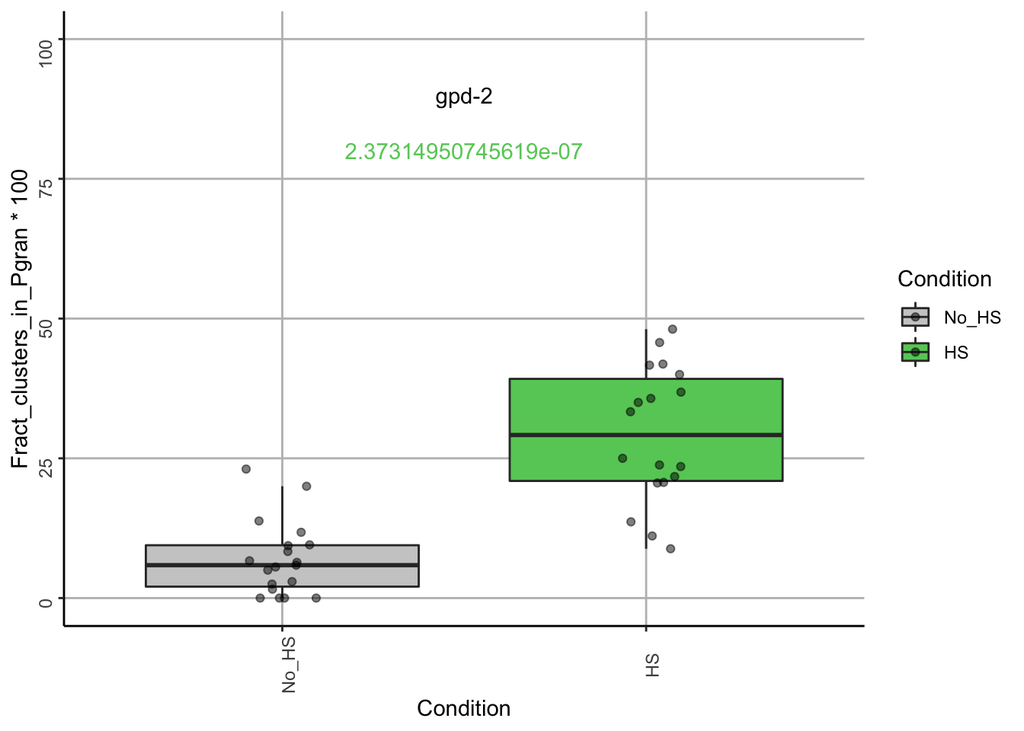

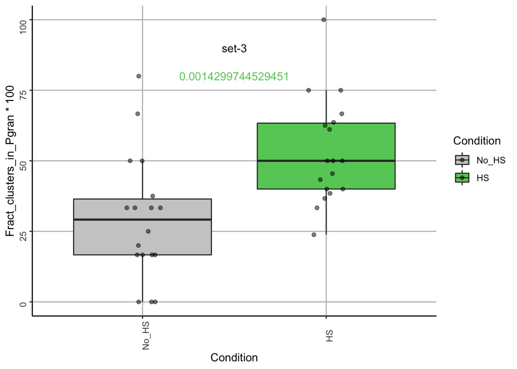

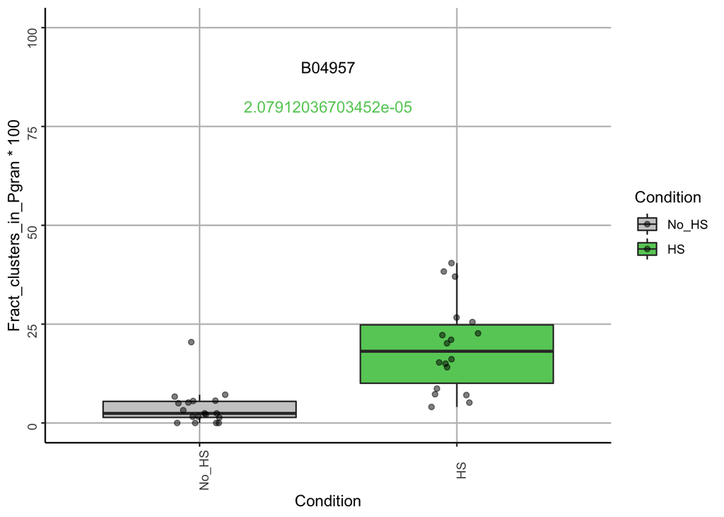

## Statistics - Raw # of clusters co-localizing with P granule markers

Now, let’s switch to looking at the raw numbers of RNA clusters for each probeset.

Are there differences between no heat shock & heat shock between the number of raw RNA clusters that co-localize with P granule markers, for each probeset?

```r
# Calculate p-values for each probe set
# Metric: total number of mRNA clusters overlapping with P granules
# Conditions: heat shock versus no heat shock conditions

# Calculate the t-test - Fract_clusters_in_Pgran
calculate_raw_pvalue <- function(data, Probeset){
  # Filter for given probeset
  transcript_quantTable <- data %>%
    filter(Probe == Probeset)

  # Save the p-value
  ttestresult <- t.test(Overlap ~ Condition, data = transcript_quantTable)

  # Return the p-value
  return(ttestresult)
}
```

```
## [1] "t.test calculation - gpd-2 Probe set; Raw # of gpd-2 clusters co-localizing to P granules in non-heat shock versus heat shock conditions:"
```

```
##
##  Welch Two Sample t-test
##
## data:  Overlap by Condition
## t = -3.0483, df = 17.554, p-value = 0.007068
## alternative hypothesis: true difference in means is not equal to 0
## 95 percent confidence interval:
##  -10.943615  -2.003753
## sample estimates:
## mean in group No_HS    mean in group HS
##            1.526316            8.000000
```

```
## [1] "t.test calculation - set-3 Probe set; Raw # of set-3 clusters co-localizing to P granules in non-heat shock versus heat shock conditions:"
```

```
##
##  Welch Two Sample t-test
##
## data:  Overlap by Condition
## t = -4.2895, df = 18.488, p-value = 0.000418
## alternative hypothesis: true difference in means is not equal to 0
## 95 percent confidence interval:
##  -8.354151 -2.868071
## sample estimates:
## mean in group No_HS    mean in group HS
##            1.666667            7.277778
```

```
## [1] "t.test calculation - B04957 Probe set; Raw # of B049457 clusters co-localizing to P granules in non-heat shock versus heat shock conditions:"
```

```
##
##  Welch Two Sample t-test
##
## data:  Overlap by Condition
## t = -4.3439, df = 17.599, p-value = 0.00041
## alternative hypothesis: true difference in means is not equal to 0
## 95 percent confidence interval:
##  -25.812666  -8.965112
## sample estimates:
## mean in group No_HS    mean in group HS
##            2.055556           19.444444
```

## Plot - Supplemental Figure - Raw # of clusters co-localizing with P granule markers

For each probeset, plot the number of RNA clusters that co-localize to P granules under non-heat schock and heat shock conditions.

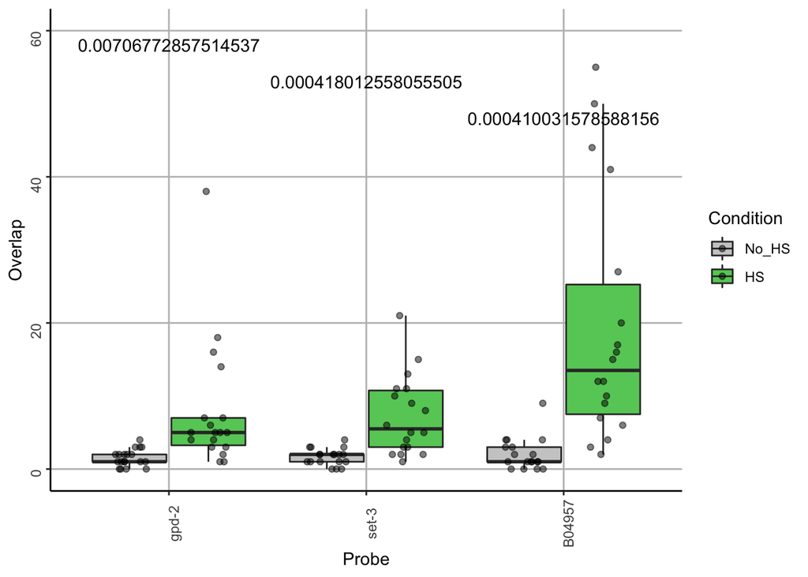

## Supplemental Figure - 13A - RNA cluster characteristics with and without heat shock

Create a figure that describes the phenotype of heat shock by illustrating how many clusters there are before and and after heat shock and also how many RNAs are expected to be within each cluster before and after heat shock.

Exploratory data analysis on the metrics:

```
## [1] 4057   10
```

```
##   Condition  Stage         Image_n  Probe index   z   y  x n_rna coloc
## 1        HS 2-cell Image_10_191016 B04957     1  86 242 19    19 FALSE
## 2        HS 2-cell Image_10_191016 B04957     2  92 300 11     9 FALSE
## 3        HS 2-cell Image_10_191016 B04957     3 100 247 22     5 FALSE
## 4        HS 2-cell Image_10_191016 B04957     4 118 428 15     7 FALSE
## 5        HS 2-cell Image_10_191016 B04957     5 115 450 17     7 FALSE
## 6        HS 2-cell Image_10_191016 B04957     6 125 465 16     7 FALSE
```

```
## 'data.frame':    4057 obs. of  10 variables:
##  $ Condition: Factor w/ 2 levels "No_HS","HS": 2 2 2 2 2 2 2 2 2 2 ...
##  $ Stage    : Factor w/ 7 levels "12-cell","14-cell",..: 4 4 4 4 4 4 4 4 4 4 ...
##  $ Image_n  : Factor w/ 41 levels "Image_01_191014",..: 25 25 25 25 25 25 25 25 25 25 ...
##  $ Probe    : Factor w/ 3 levels "gpd-2","set-3",..: 3 3 3 3 3 3 3 3 3 3 ...
##  $ index    : int  1 2 3 4 5 6 7 8 9 10 ...
##  $ z        : int  86 92 100 118 115 125 147 168 165 166 ...
##  $ y        : int  242 300 247 428 450 465 337 278 151 506 ...
##  $ x        : int  19 11 22 15 17 16 11 26 11 18 ...
##  $ n_rna    : int  19 9 5 7 7 7 7 6 8 6 ...
##  $ coloc    : logi  FALSE FALSE FALSE FALSE FALSE FALSE ...
```

Merge and process the information

```
## [1] 82 12
```

## Plot Figure S13A

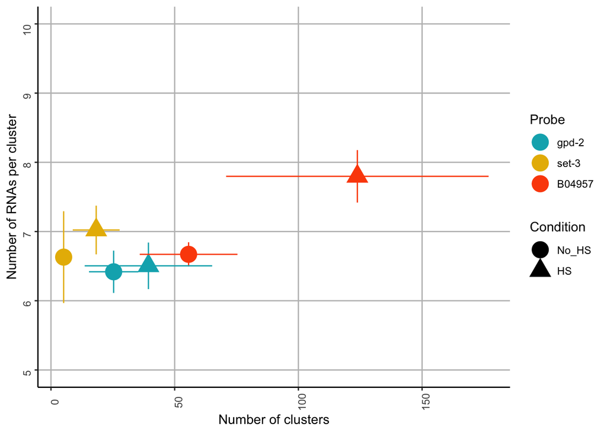